# COMPSCIX 415.2 Homework 5/Midterm

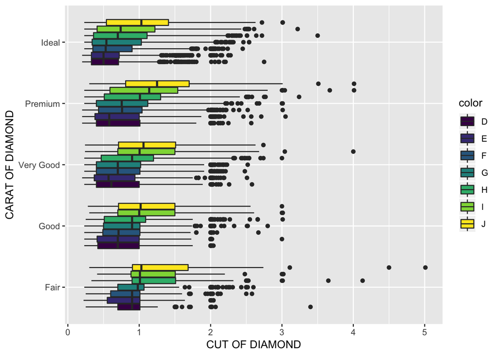

```r
a <- ggplot(diamonds, aes(cut, carat, fill=color)) +
  geom_boxplot() +
  xlab("CARAT OF DIAMOND") + ylab("CUT OF DIAMOND")
a + coord_flip()
```

#### 1. Is this data “tidy”? If yes, leave it alone and go to the next problem. If no, make it tidy. Note: this data set is called table2 and is available in the tidyverse package. It should be ready for you to use after you’ve loaded the tidyverse package.

```
## # A tibble: 6 x 4
##   country      year  cases population
##   <chr>       <int>  <int>      <int>
## 1 Afghanistan  1999    745   19987071
## 2 Afghanistan  2000   2666   20595360
## 3 Brazil       1999  37737  172006362
## 4 Brazil       2000  80488  174504898
## 5 China        1999 212258 1272915272
## 6 China        2000 213766 1280428583
```

#### 2. Create a new column in the diamonds data set called price_per_carat that shows the price of each diamond per carat (hint: divide). Only show me the code, not the output.

```r
mutate(diamonds,
  price_per_carat = price/carat)
```

```
## # A tibble: 53,940 x 11
##    carat cut   color clarity depth table price     x     y     z
##    <dbl> <ord> <ord> <ord>   <dbl> <dbl> <int> <dbl> <dbl> <dbl>
##  1 0.23  Ideal E     SI2      61.5    55   326  3.95  3.98  2.43
##  2 0.21  Prem… E     SI1      59.8    61   326  3.89  3.84  2.31
##  3 0.23  Good  E     VS1      56.9    65   327  4.05  4.07  2.31
##  4 0.290 Prem… I     VS2      62.4    58   334  4.2   4.23  2.63
##  5 0.31  Good  J     SI2      63.3    58   335  4.34  4.35  2.75
##  6 0.24  Very… J     VVS2     62.8    57   336  3.94  3.96  2.48
##  7 0.24  Very… I     VVS1     62.3    57   336  3.95  3.98  2.47
##  8 0.26  Very… H     SI1      61.9    55   337  4.07  4.11  2.53
##  9 0.22  Fair  E     VS2      65.1    61   337  3.87  3.78  2.49
## 10 0.23  Very… H     VS1      59.4    61   338  4     4.05  2.39
## # … with 53,930 more rows, and 1 more variable: price_per_carat <dbl>
```

#### 3. For each cut of diamond in the diamonds data set, how many diamonds, and what proportion, have a price > 10000 and a carat < 1.5? There are several ways to get to an answer, but your solution must use the data wrangling verbs from the tidyverse in order to get credit.

```r
my_subset <- nrow(subset(diamonds, price >= 10000 & carat < 1.5))
orig <- nrow(diamonds)
(my_subset/orig)*100.0
```

```
## [1] 1.546162
```

```r
# 1.55% of the data
```

#### Do the results make sense? Why?

#### Do we need to be wary of any of these numbers? Why?

### EDA

Take a look at the txhousing data set that is included with the ggplot2 package and answer these questions: view(txhousing)

#### 1.During what time period is this data from? The data is from 2000 to 2015

```
## [1] 2000
```

```
## [1] 2015
```

#### 2.How many cities are represented? 46 cities are presented.

```r
distinct(txhousing, city)
```

```
## # A tibble: 46 x 1
##    city
##    <chr>
##  1 Abilene
##  2 Amarillo
##  3 Arlington
##  4 Austin
##  5 Bay Area
##  6 Beaumont
##  7 Brazoria County
##  8 Brownsville
##  9 Bryan-College Station
## 10 Collin County
## # … with 36 more rows
```

#### 3.Which city, month and year had the highest number of sales?

#### Answer : Huston in July 2015 had highest, 8945 sales.

```r
arrange(txhousing, desc(sales))
```

```
## # A tibble: 8,602 x 9
##    city     year month sales     volume median listings inventory  date
##    <chr>   <int> <int> <dbl>      <dbl>  <dbl>    <dbl>     <dbl> <dbl>
##  1 Houston  2015     7  8945 2568156780 217600    23875       3.4 2016.
##  2 Houston  2006     6  8628 1795898108 155200    36281       5.6 2006.
##  3 Houston  2013     7  8468 2168720825 187800    21497       3.3 2014.
##  4 Houston  2015     6  8449 2490238594 222400    22311       3.2 2015.
##  5 Houston  2013     5  8439 2121508529 186100    20526       3.3 2013.
##  6 Houston  2014     6  8391 2342443127 211200    19725       2.9 2014.
##  7 Houston  2014     7  8391 2278932511 199700    20214       3   2014.
##  8 Houston  2014     8  8167 2195184825 202400    20007       2.9 2015.
##  9 Houston  2013     8  8155 2083377894 186700    21366       3.3 2014.
## 10 Houston  2006     5  8040 1602621368 151200    35398       5.5 2006.
## # … with 8,592 more rows
```

#### 4.What kind of relationship do you think exists between the number of listings and the number of sales? Check your assumption and show your work.

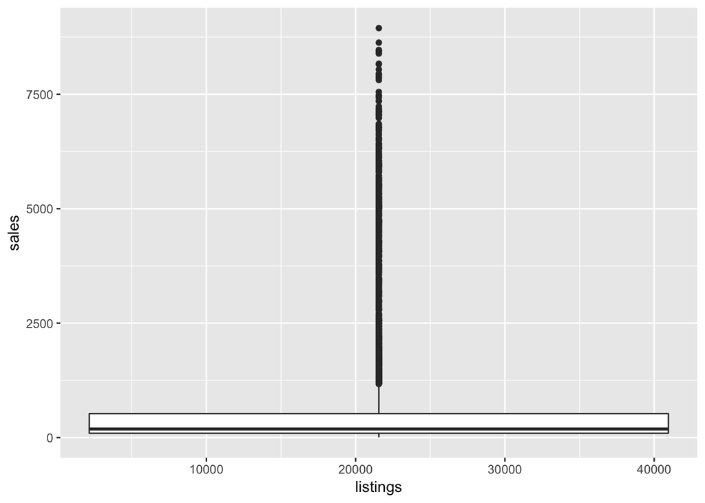

```r
ggplot(txhousing, aes(listings, sales)) +
  geom_boxplot()
```

#### 5.What proportion of sales is missing for each city?

```r
txhousing %>% group_by(city)
```

```
## # A tibble: 8,602 x 9
## # Groups:   city [46]
##    city     year month sales   volume median listings inventory  date
##    <chr>   <int> <int> <dbl>    <dbl>  <dbl>    <dbl>     <dbl> <dbl>
##  1 Abilene  2000     1    72  5380000  71400      701       6.3 2000
##  2 Abilene  2000     2    98  6505000  58700      746       6.6 2000.
##  3 Abilene  2000     3   130  9285000  58100      784       6.8 2000.
##  4 Abilene  2000     4    98  9730000  68600      785       6.9 2000.
##  5 Abilene  2000     5   141 10590000  67300      794       6.8 2000.
##  6 Abilene  2000     6   156 13910000  66900      780       6.6 2000.
##  7 Abilene  2000     7   152 12635000  73500      742       6.2 2000.
##  8 Abilene  2000     8   131 10710000  75000      765       6.4 2001.
##  9 Abilene  2000     9   104  7615000  64500      771       6.5 2001.
## 10 Abilene  2000    10   101  7040000  59300      764       6.6 2001.
## # … with 8,592 more rows
```

### 6.Looking at only the cities and months with greater than 500 sales:

```r
my_subset <- nrow(subset(txhousing, sales >= 500))
orig <- nrow(txhousing)
(my_subset/orig)*100.0
```

```
## [1] 21.96001
```

#### 6.1 Are the distributions of the median sales price (column name median), when grouped by city, different? The same? Show your work.

#### 6.2 Any cities that stand out that you’d want to investigate further?

#### 6.3 Why might we want to filter out all cities and months with sales less than 500?